# Anexo 17

### Proyecto 17: Regresión Lineal con TensorFlow

Mg. Luis Felipe Bustamante Narváez

En este ejemplo, veremos, a partir de datos aleatorios el comportamiento de un modelo de regresión lineal utilizando TensorFlow para predecir parámetros normales.

## Librerías

```python
import numpy as np
import tensorflow as tf
import matplotlib.pyplot as plt
from tensorflow.keras.layers import Dense, Input
from tensorflow.keras.models import Model
from tensorflow.keras.optimizers import Adam
```

## Creamos datos aleatorios

```python
# Total de datos
N = 200
# 200 valores aleatorios entre -5 y 4
X = np.random.random(N)*9 - 5
# Función: w=0.5, b=-1, ruido de 0.5 para 200 valores aleatorios con media 0 y desviación 1
y = (0.5*X - 1) + np.random.randn(N)*0.5
```

### Explicación

1. Se define la cantidad total de datos a generar:

**N = 200**

Esto significa que se van a crear **200 muestras** (puntos de datos). Esta variable se usa en las siguientes líneas para definir cuántos valores aleatorios se generarán.

2. Se generan **200 valores aleatorios** en el intervalo entre **-5 y 4**:

**X = np.random.random(N) * 9 - 5**

Aquí está lo que ocurre:

- **np.random.random(N)** genera 200 números aleatorios con distribución uniforme entre 0 y 1.
- * 9 escala esos valores al rango [0, 9).
- **- 5** desplaza el rango a [-5, 4).

Así que `X` será un arreglo de 200 valores aleatorios distribuidos uniformemente entre -5 y 4.

3. Se generan los valores de `y` a partir de una **relación lineal con ruido**:

y = (0.5*X - 1) + np.random.randn(N)*0.5

Esto representa una función lineal con pendiente **0.5** y ordenada al origen **-1**, a la que se le suma **ruido aleatorio** para simular datos reales. Desglosemos:

- **0.5 * X - 1** es una función lineal: `y = 0.5x - 1`.
- **np.random.randn(N)** genera 200 valores con distribución normal (media 0, desviación estándar 1).
- **0.5** ajusta el nivel del ruido: lo reduce para que tenga una desviación estándar de 0.5.

Entonces, `y` se compone de:

- Una parte **determinística** (la línea recta).
- Una parte **aleatoria** (el ruido), que simula variaciones naturales o errores de medición.

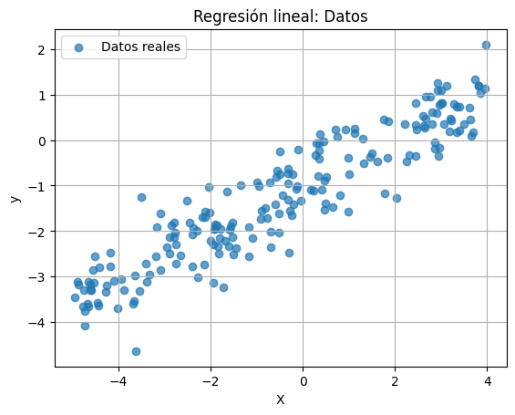

```python
#Graficamos
plt.scatter(X, y, label='Datos reales', alpha=0.7)
plt.xlabel('X')
plt.ylabel('y')
plt.title('Regresión lineal: Datos')
plt.legend()
plt.grid(True)
plt.show()
```

## Modelo

```python
i = Input(shape=(1,))
x = Dense(1)(i)
modelo = Model(i, x)
```

```python
modelo.summary()
```

```
Model: "functional"
```

```
┏━━━━━━━━━━━━━━━━━━━━━━━━━━━━━━━━━┳━━━━━━━━━━━━━━━━━━━━━━━━┳━━━━━━━━━━━━━━━┓
┃ Layer (type)                    ┃ Output Shape           ┃       Param # ┃
┡━━━━━━━━━━━━━━━━━━━━━━━━━━━━━━━━━╇━━━━━━━━━━━━━━━━━━━━━━━━╇━━━━━━━━━━━━━━━┩
│ input_layer (InputLayer)        │ (None, 1)              │             0 │
├─────────────────────────────────┼────────────────────────┼───────────────┤
│ dense (Dense)                   │ (None, 1)              │             2 │
└─────────────────────────────────┴────────────────────────┴───────────────┘
```

```
 Total params: 2 (8.00 B)
```

```
 Trainable params: 2 (8.00 B)
```

```
 Non-trainable params: 0 (0.00 B)
```

```python
modelo.compile(
    loss='mse',
    optimizer=Adam(learning_rate=0.1),
    metrics=['mae']
)
```

### Explicación

1. Se define la **capa de entrada** del modelo:

**i = Input(shape=(1,))**

Esto indica que el modelo recibirá **una sola característica** como entrada (por ejemplo, una variable `x` real).

- `shape=(1,)` significa que cada ejemplo de entrada es un número de una dimensión (como un valor de `x`).
2. Se agrega una **capa densa (neurona)** que toma la entrada:

**x = Dense(1)(i)**

- Se crea una **capa densa** con una sola neurona (`Dense(1)`), que recibe la entrada `i`.
- Esta capa aplica una operación lineal:  
  ( y = w \cdot x + b ),  
  donde `w` y `b` son los **pesos** y **sesgo** que el modelo aprenderá.
3. Se construye el modelo final especificando entrada y salida:

**modelo = Model(i, x)**

- Se crea un modelo Keras con `i` como entrada y `x` como salida.
- Esto es útil cuando se usa la API **funcional** de Keras (en lugar de la secuencial).
4. Se imprime un resumen del modelo:

**modelo.summary()**

Esto muestra una tabla con:

- Las capas del modelo.
- El tipo de cada capa.
- La cantidad de parámetros entrenables.

Como este modelo tiene solo **una neurona**, el número de parámetros será 2: el peso (`w`) y el sesgo (`b`).

5. Se **compila** el modelo, especificando cómo se va a entrenar:

**modelo.compile(**  
**loss='mse',**  
**optimizer=Adam(learning_rate=0.1),**  
**metrics=['mae']**  
**)**

- **loss='mse'**: Se usa el error cuadrático medio (*mean squared error*), típico en regresión.
- **optimizer=Adam(learning_rate=0.1)**: Se usa el optimizador **Adam** con una tasa de aprendizaje de **0.1**.
- **metrics=['mae']**: Se añade el **error absoluto medio** (*mean absolute error*) como métrica adicional.

Este modelo está diseñado para **aprender una relación lineal simple**, como por ejemplo los datos generados con `y = 0.5x - 1 + ruido`.

## Entrenamiento

```python
r = modelo.fit(
    X.reshape(-1, 1),
    y,
    epochs=800,
    batch_size=32
)
```

### Explicación

1. **X.reshape(-1, 1)**

Esto **reorganiza la forma** del array `X` para que tenga una sola columna.

- `X` originalmente tiene forma `(200,)` (200 valores sueltos).
- `X.reshape(-1, 1)` convierte eso en una matriz de **200 filas y 1 columna**: forma `(200, 1)`.

Esto es necesario porque el modelo espera **entradas bidimensionales**, aunque tenga solo una característica.

2. **y**

Este es el vector de etiquetas (los valores reales de salida), que usamos para entrenar al modelo. No hace falta cambiar su forma porque Keras acepta vectores 1D como salidas.

3. **epochs=800**

Se entrena el modelo durante **800 épocas**.

- Una época significa pasar **todos los datos de entrenamiento una vez** por el modelo.
- Entrenar durante muchas épocas ayuda al modelo a **aprender mejor**, pero también puede provocar **sobreajuste** si es excesivo.
4. **batch_size=32**

Durante cada época, los datos se dividen en **lotes (batches)** de 32 ejemplos a la vez.

- Esto hace que el entrenamiento sea más eficiente y estable.
- En cada lote, el modelo actualiza los pesos.
5. **r = ...**

La variable `r` guarda el **historial del entrenamiento**.

- `r.history` contiene los valores de la **función de pérdida** (`loss`) y la **métrica** (`mae`) en cada época.
- Puedes usarlo luego para **graficar la evolución del entrenamiento**.
6. **Muestra de la salida**

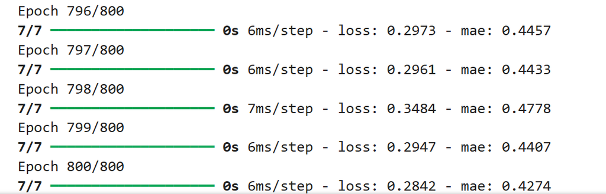

## Gráfica de la función de pérdida

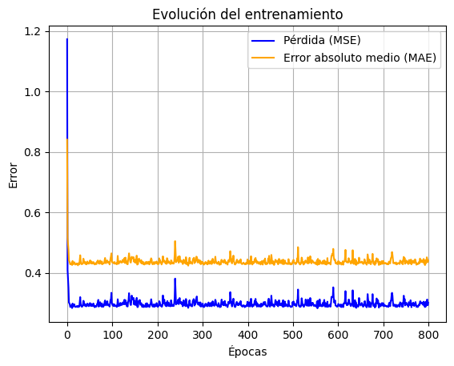

```python
# Gráfico de la función de pérdida (loss)
plt.plot(r.history['loss'], label='Pérdida (MSE)', color='blue')
plt.plot(r.history['mae'], label='Error absoluto medio (MAE)', color='orange')
plt.xlabel('Épocas')
plt.ylabel('Error')
plt.title('Evolución del entrenamiento')
plt.legend()
plt.grid(True)
plt.show()
```

## Predicción

```python
X_test = np.linspace(-5, 4, 20).reshape(-1, 1)
P_test = modelo.predict(X_test)
```

```
1/1 ━━━━━━━━━━━━━━━━━━━━ 0s 53ms/step
```

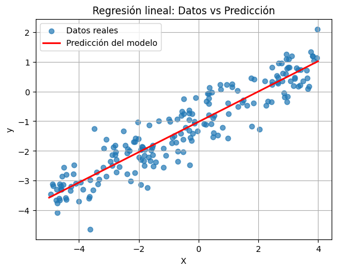

```python
plt.scatter(X, y, label='Datos reales', alpha=0.7)
plt.plot(X_test, P_test, color='red', label='Predicción del modelo', linewidth=2)
plt.xlabel('X')
plt.ylabel('y')
plt.title('Regresión lineal: Datos vs Predicción')
plt.legend()
plt.grid(True)
plt.show()
```

```python
# Métricas
modelo.layers[1].get_weights()
```

```
[array([[0.50980544]], dtype=float32), array([-1.0232817], dtype=float32)]
```

### Explicación

Esta línea se usa para **obtener los pesos entrenados** del modelo, específicamente de la **primera capa oculta** (que en este caso es también la única capa densa del modelo).

1. **modelo.layers**

Es una lista que contiene todas las **capas del modelo**.  
En este ejemplo, el modelo tiene dos capas:

- **`layers[0]`** → la capa de entrada: **Input(shape=(1,))**
- **`layers[1]`** → la capa densa: **Dense(1)**
2. **modelo.layers[1]**

Accede específicamente a la **capa densa**, que es donde están los **pesos (`w`) y el sesgo (`b`)** que se ajustan durante el entrenamiento.

3. **.get_weights()**

Devuelve una **lista con dos elementos**:

- El primer elemento es un array con el **peso (`w`)** → forma `(1, 1)` porque es una entrada y una neurona.
- El segundo elemento es un array con el **sesgo (`b`)** → forma `(1,)`.

### Ejemplo de salida esperada

Si haces un `print()` a eso después de entrenar el modelo, podrías ver algo como:

```
[array([[0.498]]), array([-0.98])]
```

Esto indicaría que el modelo aprendió aproximadamente la función:

y≈0.498x−0.98

muy cercana a la **función original** usada para generar los datos:

y=0.5x−1+ruido

## Conclusiones

TensorFlow es una biblioteca capaz de implementar redes neuronales para predecir a través de cálculos estadísticos de regresión lineal, cuando un grupo de números, se acerca a los valores reales que se desean predecir. Esta aplicación netamente teórica, puede ser implementada en clasificación de textos para NLP.

Mg. Luis Felipe Bustamante Narváez